# Trabalho Nº06 - Modelos Markovianos

Willian Meira Schlichta | GRR20159077

14 de Setembro de 2020

## Exercicio 1a

**Resolução A**

Da propriedade de Markov e da estacionariedade da sequência $C_{t}$ onde t = 1, 2, 3, temos:

$$P(C_{1}=i,C_{2}=j,C_{3}=k)=P(C_{1}=i).P(C_{2}=j|C_{1}=j).P(C_{3}=k|C_{2}=j)=
\delta_{i}\gamma_{ij}\gamma_{jk}$$

Usando a propriedade de independência condicional, obtemos:

$$P(S_{1}=0,S_{2}=2,S_{3}=1)=$$

$$=\sum_{i=1}^{2}\sum_{j=1}^{2}\sum_{k=1}^{2}P(S_{1}=0,S_{2}=2,S_{3}=1|C_{1}=i,C_{2}=j,C_{3}=k)P(C_{1}=i,C_{2}=j,C_{3}=k)$$

$$=\sum_{i=1}^{2}\sum_{j=1}^{2}\sum_{k=1}^{2}p_{i}(0)p_{j}(2)p_{k}(1)\delta_{i}\gamma_{ij}\gamma_{jk}, \;{Onde} \ p_{l}(s)=\frac{\lambda_{l}^{s}e^{-\lambda_{l}}}{s!}, \;l \;\epsilon \left \{ 1,2 \right \}$$

Então temos:

$$(\delta_{1} \ \delta_{2})=\frac{1}{0.9+0.4}(0.4 \ 0.9)=(4/13 \ 9/13)$$

E com o valor dos lambdas $\lambda_{1}=1 \;e\; \lambda_{2}=3$ obtemos:

$$p_{1}(0)\approx 0,368 \; , \; p_{1}(2)\approx 0,184 \; , \; p_{1}(1)\approx 0.368$$

$$p_{2}(0)\approx 0,05 \; , \; p_{2}(2)\approx 0,224 \; , \; p_{2}(1)\approx 0,149$$

A tabela a seguir lista todas as sequências possíveis de estados e as respectivas probabilidades:

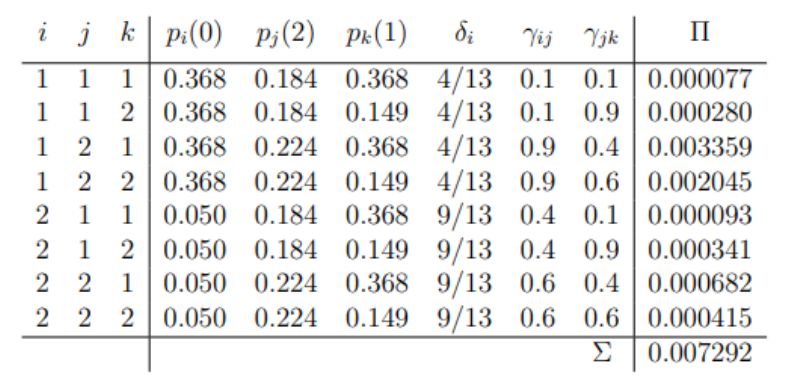

Observe que os valores da tabela podem ser usados para calcular a probabilidade condicional de cada sequência possível de estados, $C_{1}, C_{2}, C_{3}$ usando:

$P(C_{1}=i,C_{2}=j,C_{3}=k|S_{1}=0,S_{2}=2,S_{3}= 1)$

$=\frac{P(C_{1} = i, C_{2} = j, C_{3} = k, S_{1} = 0, S_{2} = 2, S_{3} = 1)}{P(S_{1} = 0, S_{2} = 2, S_{3} = 1)}, \;{}para \ i, j, k \ \epsilon \left \{ 1, 2 \right \}$

Assim, a sequência de estados mais provável aqui é $C_{1} = 1, C_{2} = 2, C_{3} = 1$ sua probabilidade condicional é dada por $\frac{0.003359}{0.007292}\approx0.461$.

## Exercicio 1b

**Desenvolvimento B**

$$P(S_{1} = 0, S_{2} = 2, S_{3} = 1) = \mathbf{\delta P(0)\Gamma P (2)\Gamma P (1)1'}$$
$$= (4/13 \ 9/13) \begin{pmatrix}
0.368 & 0 \\
0& 0.050 \end{pmatrix}
\begin{pmatrix}
0.1 & 0.9\\
0.4 & 0.6
\end{pmatrix}
\begin{pmatrix}
0.184 & 0 \\
0 & 0.0224
\end{pmatrix}
\begin{pmatrix}
0.1 & 0.9\\
0.4 & 0.6
\end{pmatrix}
\begin{pmatrix}
0.368 & 0\\
0 & 0.149
\end{pmatrix}
\begin{pmatrix}
1\\
1
\end{pmatrix} \\
\approx 0.007292$$

## Exercicio 3

**Desenvolvimento A**

Sabemos que se $X\sim P_0(\lambda)$ então $\mu=E(X)=Var(X)=\lambda$

$E(S_t)=\sum_{i=1}^{m}E(S_t\mid C_t=i)P(C_t=i)=\sum_{i=1}^{m}\lambda_i\delta_i=\mathbf{\delta\lambda{'}}$

**Desenvolvimento B**

Sabemos que se $X\sim P_0(\lambda)$ então $E(X^2)=Var(X)+E(X)^2=\lambda+\lambda^2$.

Partindo desse fato temos:

$E(S_t^2)=\sum_{i=1}^{m}E(S_t^2\mid C_t=i)P(C_t=i)$

$=\sum_{i=1}^{m}(\lambda_i+\lambda_i^2)\delta_i=\sum_{i=1}^{m}\lambda_i^2 \delta_i+\sum_{i=1}^{m}\lambda_i\delta_i$

$= \mathbf{\lambda D \lambda{'}+\delta\lambda{'}}$

## Exercicio 5

Desenvolver da seguinte forma: simule um HMM Poisson com três estados, $\lambda=(1,5,10)$ e mesma matriz de probabilidades de transição apresentada. Estime a função de autocorrelação da Cadeia de MArkov subjacente e interprete.

**Desenvolvimento**

Modelo gerado pela função *hmmspec* do pacote *mhsmm* com valores de $\Gamma$ e $\lambda's$ solicitados:

```
Hidden Markov Model specification:
J (number of states):
3
init:
[1] 0.3333 0.3333 0.3333
transition:
       [,1]   [,2]   [,3]
[1,] 0.3333 0.3333 0.3333
[2,] 0.6667 0.0000 0.3333
[3,] 0.5000 0.5000 0.0000
emission:
$lambda
[1]  1  5 10
```

$\lambda's$ estimados via simulação com 1000 repetições:

```
[1] 1.045
[1] 5.044
[1] 9.627
```

Plotando a função de autocorrelação da série simulada:

```
 [1] -0.26  0.07 -0.04 -0.01  0.02 -0.03  0.02 -0.02 -0.02  0.01 -0.02 -0.03
```

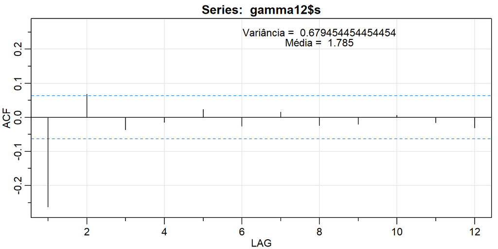